Had problems creating histogram in base `R` package.

```
## stat_bin: binwidth defaulted to range/30. Use 'binwidth = x' to adjust this.
```

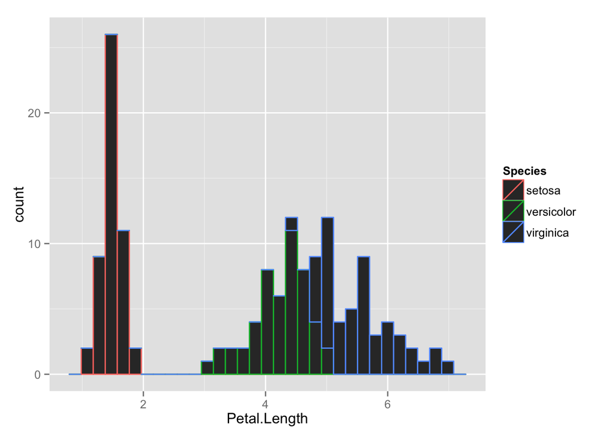

```r
library(ggplot2)
qplot(x=Petal.Length, color=Species, data=iris, geom="histogram")
```

6. Perform a one-way ANOVA to test the differences in $Petal.Length$ by $Species$. Use the 5% significance level. Also, perform a multiple comparison test to determine the order of petal lengths by species. Write the relevant details on your exam paper.  
   **Solution**  
   Model: $y_{ij} = \mu + \tau_i + \varepsilon_{ij}$ where
- $y_{ij}$ is petal length for $i^{th}$ population (*setosa, versicolor, virginica*) and $j^{th}$ observation within that population.
- $\mu$ is grand mean for all populations.
- $\tau_i$ is the population effect of $i^{th}$ population.
- $\varepsilon_{ij}$ is the error term (random variation), which is independent and normally distributed with $\mu_{\epsilon} = 0$ and standard deviation $\sigma_{\epsilon}$.

$H_0: \tau_{setosa} = \tau_{versicolor} = \tau_{virginica} = 0$  
$H_a:$ at least one population’s effect is non-zero.  
T.S.: $F = \frac{MSTrt}{MSE}$

```r
iris.aov <- aov(formula=Petal.Length ~ Species, data=iris)

#oneway.test(formula=Petal.Length ~ Species, data=iris, var.equal=TRUE)
summary(iris.aov)
```

```
##              Df Sum Sq Mean Sq F value Pr(>F)
## Species       2  437.1  218.55    1180 <2e-16 ***
## Residuals   147   27.2    0.19
## ---
## Signif. codes:  0 '***' 0.001 '**' 0.01 '*' 0.05 '.' 0.1 ' ' 1
```

*p*-value is less than 5%. We reject the null hypothesis. At least one population’s petal length is different from the rest of the populations.

After it is known that at least one of the populations was different, pairwise comparisons can be used to determine which populations are different.

**Tukey pairwise test**

```r
TukeyHSD(x=iris.aov, conf.level=0.95)
```

```
##   Tukey multiple comparisons of means
##     95% family-wise confidence level
##
## Fit: aov(formula = Petal.Length ~ Species, data = iris)
##
## $Species
##                       diff     lwr     upr p adj
## versicolor-setosa    2.798 2.59422 3.00178     0
## virginica-setosa     4.090 3.88622 4.29378     0
## virginica-versicolor 1.292 1.08822 1.49578     0
```

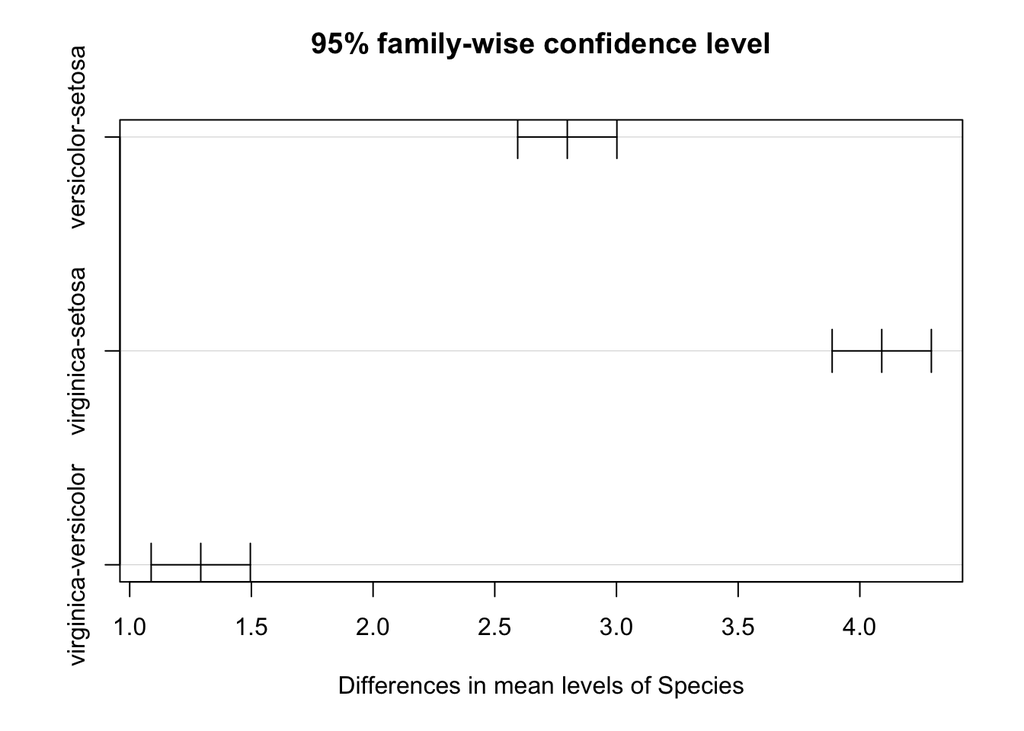

```r
plot(TukeyHSD(x=iris.aov, conf.level=0.95)) # add `las=1` `to plot()` for horizontal labels
```

```r
# Alternative to `plot()`
#library(mosaic)
#mplot(TukeyHSD(x=iris.aov, conf.level=0.95))
```

The output shows each pairwise comparison: the mean difference (`diff`) and the confidence interval (`lwr` and `upr`) of their difference. `p adj` is the *p*-value. With *p*-values of zero, the differences for each group is significant.

An equivalent Tukey pairwise test can done using the `agricolae` library. The `HSD.test()` function requires following parameters:

- `y`: ANOVA object that comes from using the `aov()` function.
- `trt`: The exact name of treatment variable that was entered in `aov()` function.
  - not sure how to enter multiple treatments for two-way ANOVA.

The default for signficance is $\alpha=0.05$.

```r
library(agricolae)
tukey.pairs <- HSD.test(y=iris.aov, trt="Species")
tukey.pairs$groups
```

```
##          trt means M
## 1 virginica  5.552 a
## 2 versicolor 4.260 b
## 3 setosa     1.462 c
```

The column `M` are groupings. If two or more treatments are not considered different from each other, they would be assigned the same letter. Here we see that each treatment has a different letter, so they are all different from each other.

**Fisher’s Least Significant Difference**  
There doesn’t appear to be a Fisher LSD test in base `R`. Use `LSD.test()` function from the `agricolae` package. See above for parameter descriptions.

```r
library(agricolae)
fisher.pairs <- LSD.test(y=iris.aov, trt="Species")
fisher.pairs$groups
```

```
##          trt means M
## 1 virginica  5.552 a
## 2 versicolor 4.260 b
## 3 setosa     1.462 c
```

Interpretation is the same as output of `HSD.test()`.